# Outside Item Memory

> This notebook focuses on item memory outside the rooms.

# 1 Overview of the data

The rooms were separated into *Familiar* and *Novel* groups. Participants explored the *Familiar* group at the beginning of the experiment. In the encoding task, they visisted both *Familiar* and *Novel* groups. Their item memory (i.e., in which room they saw the item) was tested in the memory test the next day of the encoding task. **Novelty benefits** on the item memory are examined by comparing the memory performance between the *Familiar* and *Novel* groups.

Participants were also asked to rate how curious they felt about the room. The higher the rating is means they felt more curious about the room. Item memory as a function of curiosity rating was also examined for **curiosity benefits**.

Questionnaires on personal traits regarding curiosity were also administered to participants before the encoding task (i.e., PC and EC). Scores on these questionnaires might be able to predict the item memory or its relationship with curiosity rating.

In the encoding task, there were 6 objects in each room. It is possbile that the item memory for the object to some extent depends on the order in which the object was seen. For example, it may be easier to remember where the first and last objects were seen as compared to those in the middle.

# 2 Visual inspection of the data

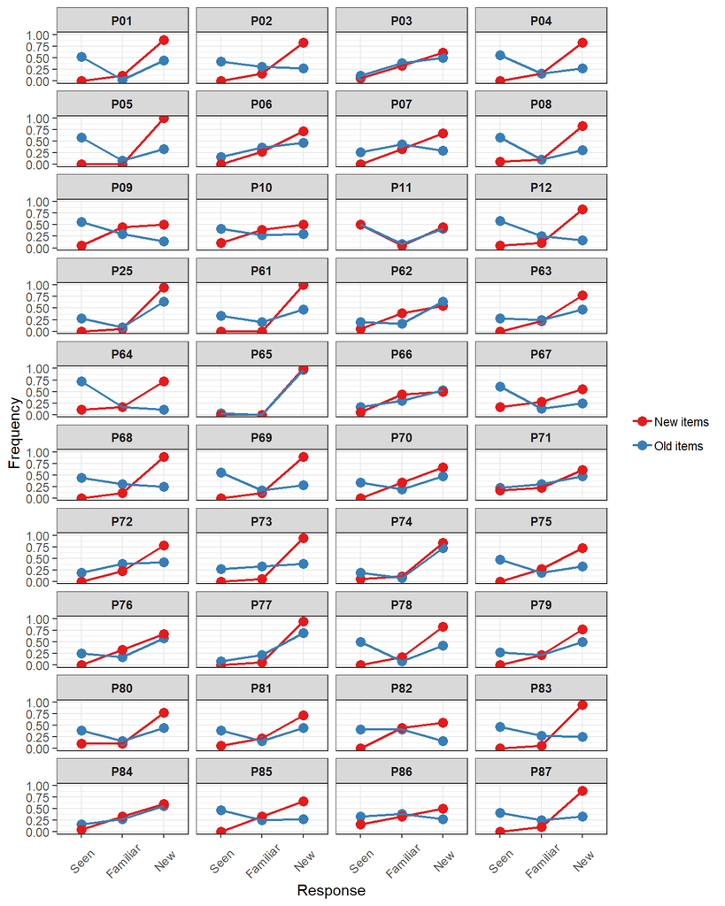

Figure 1. Response frequency for new and old items respectively for each individual participant.

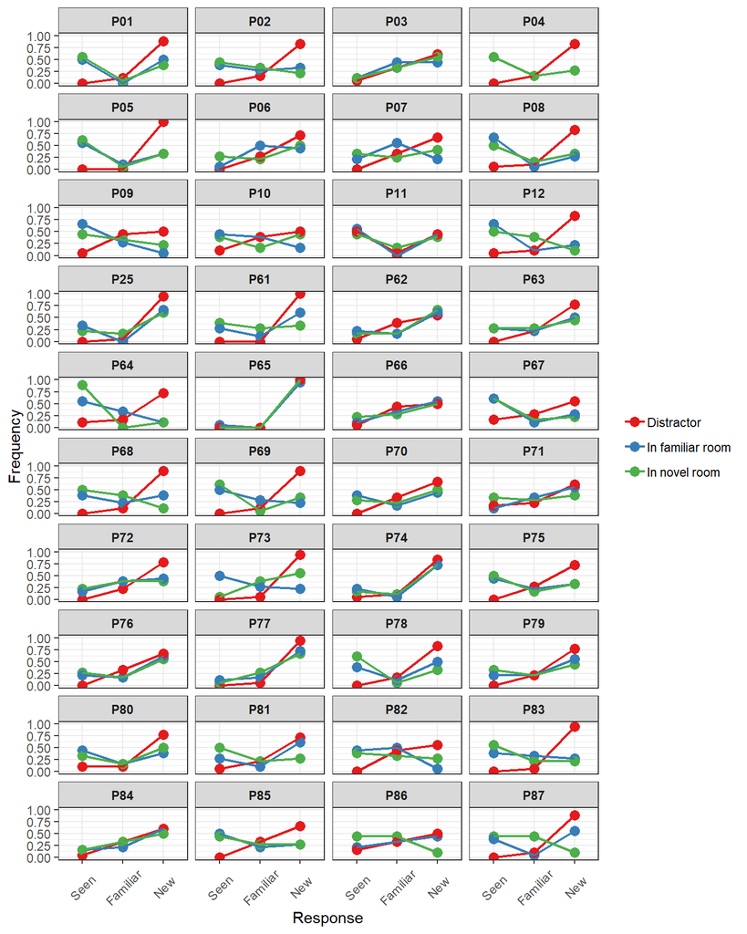

Figure 2. Response frequency for new and old items respectively for each Familiar/Novel group and each individual participant.

# 3 Novelty Benefits

We hypothesised that the memory for the items outside the rooms should be better for the *novel* rooms than for the *familiar* rooms.

## 3.1 Compare mean accuracy between *novel* and *familiar* rooms

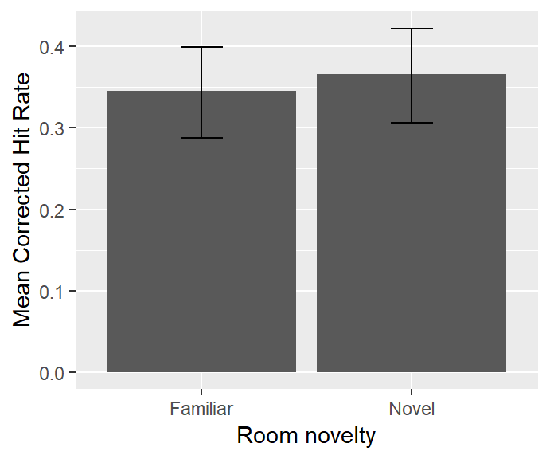

Figure 3. Mean hit rate for recollect response respectively for Familiar and Novel rooms.

```
##
##  Paired t-test
##
## data:  MeanCorrSeenHit by Group
## t = -0.90532, df = 39, p-value = 0.3709
## alternative hypothesis: true difference in means is not equal to 0
## 95 percent confidence interval:
##  -0.06638149  0.02533211
## sample estimates:
## mean of the differences
##             -0.02052469
```

## 3.2 Item memory as a function of item order

### 3.2.1 Visualise the data

#### 3.2.1.1 Nonlinear

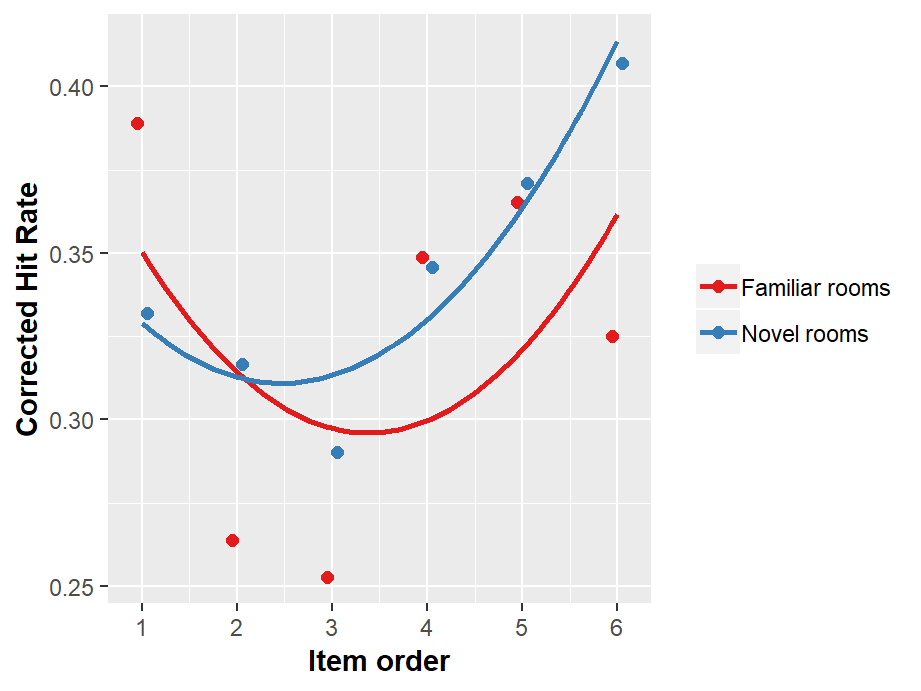

Figure 4. Mean hit rate for seen response at each order (i.e., 1st, 2nd, 3rd, etc), respectively for familiar and novel rooms.

#### 3.2.1.2 Linear

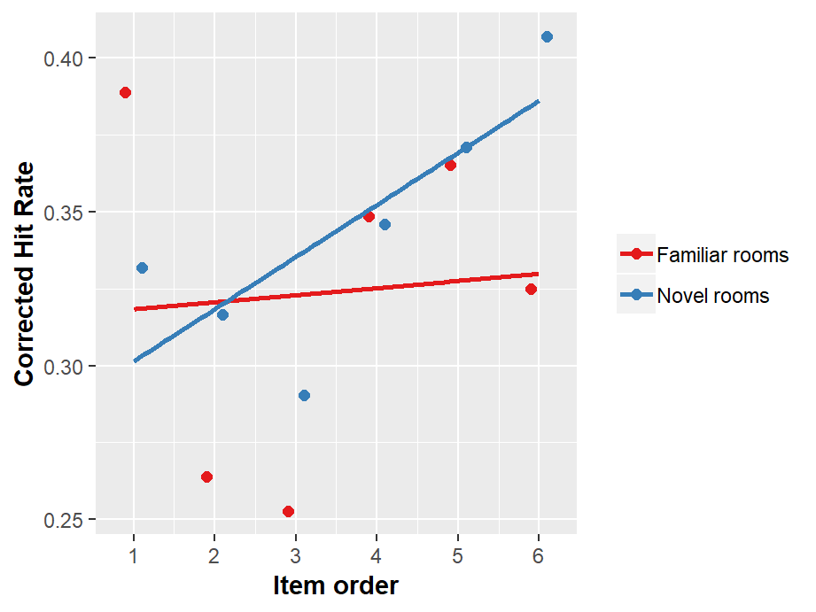

Figure 5. Mean hit rate for seen response at each order (i.e., 1st, 2nd, 3rd, etc), respectively for familiar and novel rooms.

### 3.2.2 Testing novelty effects by fitting mixed models

Build models with item memory accuracy as $y$ and then examine effects of novelty by comparing the models.

```
##                      Model df      AIC      BIC    logLik   Test   L.Ratio
## baseline.item            1  4 103.6804 120.3756 -47.84021
## order.model.linear.1     2  5 103.5972 124.4661 -46.79861 1 vs 2 2.0831973
## novelty.model.1          3  6 104.8492 129.8919 -46.42460 2 vs 3 0.7480299
## novelty.model.2          4  7 105.6368 134.8533 -45.81838 3 vs 4 1.2124251
##                      p-value
## baseline.item
## order.model.linear.1  0.1489
## novelty.model.1       0.3871
## novelty.model.2       0.2709
```

### 3.2.3 Collapse the order and novelty group

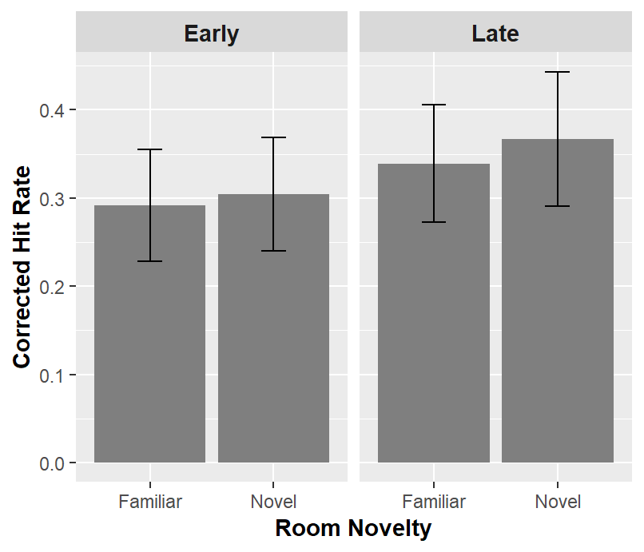

#### 3.2.3.1 Stats on it

##### 3.2.3.1.1 Using `lme`

```
##               Model df       AIC       BIC   logLik   Test  L.Ratio
## baseline          1  5 -83.66328 -68.28741 46.83164
## NoveltyModel      2  6 -82.42356 -63.97252 47.21178 1 vs 2 0.760289
## OrderModel        3  7 -86.22135 -64.69514 50.11068 2 vs 3 5.797789
## repeatedModel     4  8 -84.33658 -59.73518 50.16829 3 vs 4 0.115222
##               p-value
## baseline
## NoveltyModel   0.3832
## OrderModel     0.0160
## repeatedModel  0.7343
```

```
##                        Value  Std.Error DF   t-value      p-value
## (Intercept)       0.28784722 0.03149853 79 9.1384324 5.221472e-14
## GroupNovel        0.02013889 0.02272359 39 0.8862545 3.809128e-01
## ItemOrderTypeLate 0.05486111 0.02272359 79 2.4142797 1.807904e-02
```

Only a main effect of item order.